# The Power of Star Creators: Evidence from the Live Streaming Industry

Converted from PDF `Qian-StarCreatorsLivestreaming-2026-JMR.pdf` · 18 pages · anchors: page `#pN`, block `#pN-bK`

Page 1

## The Power of Star Creators: Evidence from the Live Streaming Industry

#### Kun Qian and Ying Xie

Abstract In this article, the authors examine the impact of star creator exits on digital content markets, leveraging exogenous events on Twitch. Using a synthetic difference-in-differences approach, they estimate the causal effects of star creators’ exits from the live streaming platform. Their findings reveal that, at the live streaming category level, the exit of a star creator leads to a sizable decrease in both content provision and consumption within the star creator’s focal category. At the individual creator level, the effects are heterogeneous, varying by the creator’s audience size and contractual status with the platform. Major creators reduce their content provision, while micro creators maintain their streaming activity, though both groups experience a decline in viewership. Additionally, contracted creators tend to sustain their content provision levels following a star creator’s exit, whereas noncontracted creators exhibit a significant decline. Lastly, the authors find that the impact of a star creator’s departure persists for several months, indicating a lasting effect at both the category and individual levels.

Keywords market exit, stardom, content creation, live streaming, synthetic difference-in-differences

Online supplement: https://doi.org/10.1177/00222437251359163

Submitted April 29, 2023

The proliferation of digital content platforms has transformed content creation, enabling millions of users worldwide to generate and distribute content. As of December 2024, YouTube, the leading video-sharing platform, hosted over 114 million active channels with 500 hours of new video uploaded every minute (Hayes 2024). The sustainability of these platforms hinges on a continuous provision of high-quality content in large volume and variety. To stimulate content creation, platforms employ various incentives, including monetary rewards (in the form of revenue sharing and consumer donations), creator tools (e.g., YouTube Studio editor), and creator recruitment or retention programs (e.g., YouTube Partner Program).

Despite these efforts, success among content creators remains highly concentrated. Only an estimated .06% of YouTube creators have surpassed the 1 million subscriber milestone, a threshold often associated with financial viability (Kumar 2025). This concentration is particularly pronounced in digital entertainment, where a small number of star creators dominate consumer attention. For instance, PewDiePie, a prominent YouTuber, amassed 110 million subscribers and 29 billion total views by the end of 2024. This heavy reliance on a few star creators raises concerns about market stability and diversity. While these creators drive engagement and revenue, their dominance may also pose barriers for emerging creators seeking visibility and audience growth.

Given the skewed nature of digital content markets, understanding the role of star creators in shaping content provision and consumption is crucial for effectively managing these complex markets. Although the rise of star creators has received increased media attention, many fundamental questions remain unanswered. The implications of star creators for the content provision incentives of nonstar creators are particularly ambiguous. On the one hand, star creators can enhance the platform’s ecosystem by attracting a larger audience, potentially benefiting all creators. On the other hand, their dominance may intensify competition, making it harder for nonstar creators to gain visibility and sustain content production. Moreover, these effects may vary significantly depending on a creator’s audience size, platform engagement, and contractual agreements. The coexistence of multiple mechanisms and the high degree of heterogeneity in creators underscore the complexity of star creators’ market influence and the need for empirical investigation.

In this article, we explore how the exit of a star creator affects content provision and consumption at both the market

Kun Qian is Assistant Professor of Marketing, Isenberg School of Management, University of Massachusetts Amherst, USA (email: kunqian@isenberg.umass. edu). Ying Xie is Professor of Marketing, Naveen Jindal School of Management, University of Texas at Dallas, USA (email: Ying.Xie@utdallas.edu).

Article

Journal of Marketing Research

2026, Vol. 63(1) 149-166 © American Marketing Association 2025

Article reuse guidelines: sagepub.com/journals-permissions DOI: 10.1177/00222437251359163

journals.sagepub.com/home/mrj

Page 2

level and the individual creator level. Drawing from extant literature on prominent firms’ market entry and exit, stardom, and content creation incentives, we develop and test hypotheses predicting that: (1) a star creator’s market exit will reduce both content consumption and provision in the affected category, and (2) at the individual level, the response of nonstar creators to a star’s departure will vary based on their audience size and contractual status. Specifically, we expect that major creators (those with a substantial following) will experience a greater negative impact on both content provision and viewership compared with micro creators (those catering to niche audiences). Additionally, we predict that noncontracted creators will be more adversely affected than contracted creators.

Our article makes several key contributions. First, our study explores the market power of prominent players in a new empirical context. The literature suggests that the entry or exit of a prominent firm can reshape market competition and influence

incumbent firms’ pricing behaviors in the retail and hospitality industries. We provide empirical evidence on the market power of star creators, the prominent players in digital content markets, demonstrating that their departure significantly reduces the quantity of content production. Second, we contribute to the stardom literature by investigating the influence of star creators in the market of live streaming, a new yet very popular digital entertainment form. Our study is one of the first to examine how the presence of a star player affects the supply of creative efforts in the entertainment industry. Our results suggest that the departure of star creators, in addition to the disruption to consumers, has a significant and lasting impact on nonstar creators, complementing existing research that exclusively focuses on the effect of star power on consumer demand. Third, we advance the rapidly growing literature on digital content creation incentives by showing that noncontracted creators are more vulnerable to market shocks, whereas commitment to content production due to contractual obligations mitigates the negative effects. Our research bridges these three separate streams of literature and provides empirical evidence to enrich our understanding of the market power of star creators.

The rest of the article is organized as follows. First, we develop our hypotheses based on the extant literature. Then, we conduct an empirical analysis and present our findings with several robustness checks. Lastly, we conclude with our findings, provide managerial implications, summarize the limitations of our article, and discuss the potential for future research.

#### Theoretical Background

In this section, we develop a theoretical framework to analyze how a star creator’s exit from a content market affects content consumption and provision at both the market level and the individual creator level. We formulate hypotheses by integrating insights from the literature on (1) market entry and exit of prominent firms, (2) the stardom effect, and (3) empirical studies on live streaming and content creation incentives.

#### The Effects of Star Creator’s Exit at the Market Level

The influence of star creators in content markets resembles the impact of prominent firms in traditional industries. To understand how the exit of a star creator can impact the content market, we first draw from empirical research on market entry and exit of prominent firms. Many empirical studies on market entry and exit use observed exogenous shocks to examine the impact of prominent firms using a quasi-experimental method. The main purpose is to identify the change in market outcomes before and after the shock rather than to discover the underlying demand or supply function. Taking this approach, prior research shows that the entry of prominent firms, such as Walmart in retail or Airbnb in hospitality, diminishes the market performance of incumbent firms (e.g., Ailawadi et al. 2010; Gielens et al. 2008; Jia 2008; Seamans and Zhu 2014; Singh, Hansen, and

150 Journal of Marketing Research 63(1)

Page 3

Blattberg 2006). In addition, prior studies have shown that the departure of a major supplier can significantly reduce an aggregator platform’s website traffic (Akca and Rao 2020; Chiou and Tucker 2017).

Beyond the literature on market entry and exit of prominent firms, stardom literature similarly emphasizes that star performers substantially enhance audience demand across industries like film, theater, and sports (e.g., Basuroy, Chatterjee, and Ravid 2003; Elberse 2007; Han and Ravid 2020). These studies highlight the significant consumer appeal of stars, attributing their influence to superior talent, reputation, or brand equity. Based on these two literature streams, we argue that the absence of star players can decrease the overall consumption of the entertainment product or service. Such a demand-dampening effect may be exacerbated when a star creator leaves one platform for another, considering star creators’ ability to command millions of followers. The loyalty of followers is typically rooted in the star creator’s appeal rather than the platform itself, making it likely that they will migrate to a competing platform. Furthermore, the loss of a star creator could lower the overall content quality of the platform, further diminishing the market size. Thus, we propose that a star creator’s exit can lead to a decline in overall content consumption in the content market(s) associated with the star creator.

Regarding supply-side effects, prior literature suggests that the entry of a prominent firm can intensify competition, harm incumbents’ sales, and compel them to lower prices (e.g., Ailawadi et al. 2010). Conversely, the exit of a prominent firm may soften competition and enable incumbents to raise prices. For instance, Ozturk, Venkataraman, and Chintagunta (2016) find that the exit of the Chrysler dealership led to a 1% price increase among incumbent automobile dealerships, suggesting that reduced competition allows incumbents to soften pricing strategies. In digital content markets, star creators function similarly to prominent firms within their specialized markets; therefore, their market exit is expected to soften competition among incumbent creators. Unlike traditional industries, such as retail and hospitality, where firms primarily compete on price, content creators compete by deciding how much effort to invest in producing content (Jain and Qian 2021). Consequently, the exit of a star creator may reduce competitive intensity, prompting incumbent creators to lower their content production efforts. Moreover, anticipating a decline in consumer demand, creators may further scale back their content provision. With both market competition softening and anticipated declines in content consumption, we expect an overall reduction in content provision at the market level following a star creator’s exit.

Furthermore, the anticipated reduction in content production efforts may exacerbate declining content consumption, resulting in a further decline in content consumption at the market level after a star creator’s exit. Formally, we state the following hypothesis to summarize the net effects of a star creator’s exit on content consumption and provision:

H1: A star creator’s exit has a negative net effect on the content consumption and content provision of the market(s) associated with the star creator.

#### The Heterogeneous Effects of a Star Creator’s Exit on Incumbent Creators

The impact of a star creator’s market exit on incumbent creators is unlikely to be uniform. Prior studies have shown heterogeneous effects of a prominent firm’s market entry or exit on incumbents (e.g., Ailawadi et al. 2010; Goli and Chintagunta 2021; Li and Srinivasan 2019; Orhun, Venkataraman, and Chintagunta 2016; Zervas, Proserpio, and Byers 2017). For example, Orhun, Venkataraman, and Chintagunta (2016) indicate that a theater’s market entry affects the quality provision of co-owned theaters more severely than independent competitors. Zervas, Proserpio, and Byers (2017) and Li and Srinivasan (2019) document that the impact of Airbnb’s entry varies by hotel type, with low-end hotels suffering greater sales losses than high-end hotels.

In digital content markets, creators vary significantly in audience size and their contractual relationship with platforms, leading to different responses to changes in market conditions. Previous studies on influencer marketing (e.g., Gu, Zhang, and Kannan 2024; Tian, Dew, and Iyengar 2024) classify creators as mega or micro creators based on audience size. Mega creators attract broad audiences and compete directly with other mega creators, while micro creators appeal to small but niche groups with less overlap. In this study, we define a star creator as the most prominent mega creator in a specialized content market. To distinguish nonstar mega creators, we refer to them as “major creators.” Due to their broad appeal and shared target audiences, major creators resemble star creators more closely than micro creators do. Prior research on prominent firms’ entry and exit suggests that firms with similar characteristics to a departing prominent firm experience greater disruptions than those with dissimilar characteristics. Applied to digital content markets, this suggests that major creators will be more affected by a star creator’s exit than micro creators. Two key mechanisms underlie this expectation. First, the migration of loyal followers to another platform disproportionately affects major creators, as they share a larger portion of their audience with the departing star than micro creators. Second, since major creators are direct competitors to the star creator, they are more likely to adjust their content production efforts in response to reduced competition, potentially decreasing their output more than micro creators. In summary, we posit the following hypothesis:

H2: The negative effects of a star creator’s exit on incumbent creators are more pronounced among major creators than micro creators.

Additionally, platforms often use contracts to regulate content creators’ behavior and strengthen their commitment to

Qian and Xie 151

Page 4

content provision. Previous studies (e.g., Li, Liao, and Xie 2021; Li, Shi, and Zhao 2025) find that contracted creators exert more creative effort than noncontracted creators when market conditions improve. We hypothesize that contracted creators also exhibit greater resilience to negative market shocks, such as the exit of a star creator. Due to contractual obligations, they have stronger incentives to maintain their preshock content provision levels compared with their noncontracted counterparts. Moreover, some incumbent creators may attempt to capture lost viewership by expanding their market share. Contracted creators, benefiting from greater platform support, are expected to have greater opportunities to expand their market share after the star creator’s exit than noncontracted creators. Taken together, we have the following hypothesis:

H3: The negative effects of a star creator’s exit on incumbent creators are more pronounced for noncontracted creators than for contracted creators.

#### Empirical Analysis

Our empirical analysis centers on Twitch, an ideal platform for studying the power of star creators for two reasons. First, it is the world’s largest live streaming platform, with 140 million monthly active users (Dean 2023), and attracts top streamers to create content. Second, Twitch features over 20,000 streaming categories that cater to diverse content markets, each attracting streamers who specialize in producing content within that category. The exit of a star streamer who primarily streams in one or a few categories is, therefore, unlikely to affect streamers and viewers of unrelated categories, allowing us to identify eligible control conditions for quasi-experimental studies.

We proceed by outlining our data collection and research design, followed by conducting two sets of SDiD analyses to test our hypotheses: (1) a category-level analysis to examine how total content consumption and provision are affected by the star creator’s exit, and (2) an individual-level analysis to examine how the exit of a star creator affects different types of incumbent streamers. Lastly, we assess the robustness of our findings by analyzing a second star creator’s exit and extending the observation window.

#### Data and Descriptives

We obtain data from SullyGnome (sullygnome.com), a thirdparty website that records the broadcasting activities and performance of Twitch streamers. The website archives all Twitch stream sessions using the Twitch application programming interface. From this source, we first collect data at the category level, where categories are defined by Twitch. This includes a wide array of gaming categories named after specific video games (e.g., League of Legends) and several nongaming categories (e.g., “Just Chatting”). For each streaming category, the website tracks the daily average number of concurrent channels and concurrent viewers. In 2019, the most streamed categories were primarily gaming-related. FN had the highest daily

average, with 8,212 concurrent channels, followed by League of Legends (2,792) and Apex Legends (2,503). The three most watched categories, in terms of daily average concurrent viewers, were League of Legends (127,689), FN (120,348), and Just Chatting (86,737).

To study how the exit of a star creator affects incumbent creators, we also collect information on the streaming activities of individual streamers from the same source. In total, SullyGnome recorded 177,763,457 stream sessions from 10,632,084 Twitch streamers across 20,775 categories in 2019, totaling 433 million hours of streaming content, or an average of 40.7 hours per streamer. We collect individual-level data, including each streamer’s unique channel ID, primary streaming language, channel creation date, participation in mature content streaming, and status in the Twitch Partner Program. We also record the start and end times of each stream session, allowing us to calculate the duration of each session in minutes (duration) and track the average concurrent viewers during each live streaming session (viewers). Furthermore, we distinguish duration and viewers within each session by category, recognizing that a streamer may broadcast content across multiple categories in a single session.

#### Research Design

In our empirical context of the live streaming market, star creators possess two distinctive characteristics: (1) they are market leaders with a broad audience and a significant number of followers, and (2) they are major competitors and role models for many nonstar creators. With these criteria in mind, we employ the following approach to identify star creators on Twitch. First, we search Google using the keywords “best Twitch streamers” and “top Twitch streamers,” reviewing the first ten pages of organic search results from January 1, 2019, to June 30, 2019. Second, we pinpoint the Twitch IDs of the streamers mentioned in these search results. Third, we identify streamers whose Twitch ID appears at least twice in the search results as star streamers. The number of mentions in these sources reflects not only the popularity of these streamers among consumers but also their recognition by media outlets and peers. Using this approach, we identify 26 individual star streamers on Twitch. Figure W1 in the Web Appendix illustrates the number of mentions for these star streamers. The top four streamers with the highest number of mentions are Ninja (20 mentions), Shroud (16 mentions), DrDisrespect, and TimTheTatman (each with 9 mentions). Figures W2 and W3 present the number of followers and concurrent viewers of these star streamers on Twitch as of December 31, 2019, respectively. Both metrics support our identification strategy by demonstrating the wide popularity these star streamers had on the platform. In addition to these individual streamers, some Twitch channels are operated by organizations, including esports associations and video game publishers, or by nonstreamer celebrities with a large following. We classify these as organizational channels and designate them as star creators if they are the most popular channels in their categories. For

152 Journal of Marketing Research 63(1)

Page 5

example, Riot Games, the game developer of League of Legends, was the number one channel in the League of Legends category, earning 4.4 million followers and 55,493 concurrent viewers in 2019, qualifying it as a star creator.<sup>1</sup>

Nonstar creators were defined as those not classified as star creators.

Among all identified star creators, we observed two exit events in 2019. The first event involved Ninja (Richard Tyler Blevins), who had amassed a record 14.7 million followers and 479 million total views on Twitch by July 29, 2019, his final streaming day on Twitch. On August 1, 2019, Ninja announced on Twitter that he was leaving Twitch to join Mixer, a significantly smaller live streaming platform that, at the time, held only about 3% of the market share. The second event was the exit of Shroud (Michael Grzesiek), who had 7.1 million followers and 364 million total views when he exited Twitch on October 24, 2019. He also joined Mixer and broke the news to the public on Twitter the same day he exited Twitch. Figure 1 provides screenshots of the public announcements for these two events. To our knowledge, neither streamer publicly announced their intention to leave Twitch beforehand, nor was there media speculation about their exits prior to the events.<sup>2</sup> This lack of pre-exit signals was also reflected in the Google Trends indexes, which showed no significant search volumes for keywords associated with Ninja’s exit or Shroud’s exit until their announcements were made (see Figure W4 in the Web Appendix). Given this evidence, we believe it is safe to conclude that both exit events were unexpected to the Twitch and Mixer communities. This sudden shift supports the unpredictability of these exits, aligning with the assumptions necessary for our quasi-experimental design.

The departure of star creators from Twitch to Mixer raises questions about the causal impacts of a star creator’s exit, which could be confounded by Mixer’s concurrent recruiting and promotional efforts targeting both streamers and consumers. To address this, we collect additional data and conduct two analyses. First, we obtain data from Social Blade (socialblade.com) on the 1,000 most-followed Mixer channels throughout 2019, tracking channel IDs, follower counts, and total views at the daily level. A comparison of all English-speaking Twitch streamers and the top 1,000 Mixer channels reveals that most streamers exclusively broadcast on one platform, and the departures of Ninja and Shroud did not affect Twitch streamers’ platform choices around the time of these two events.<sup>3</sup> In Figure W5, we plot the daily total views for the top 1,000 Mixer channels during our study period,

with the first vertical dashed line indicating Ninja’s move and the second marking Shroud’s move. The plot shows two shortlived increases in viewership immediately after each move, but these gains gradually diminished. No other significant changes in Mixer viewership were observed during our study period. Second, we collect data from Google Trends and plot the weekly search volume for Mixer in 2019 in Figure W6 of the Web Appendix. The search volume remained stable throughout the year and showed no significant change around the time of Ninja’s or Shroud’s exits. These findings help mitigate concerns that concurrent promotions by Mixer confounded the observed effects of the exits. Furthermore, a news report revealed that Mixer’s lucrative contracts were a key factor in these moves (Kim 2019). This evidence supports our assumption that the exits of these star creators from Twitch influenced content consumption and provision on the platform solely through their exit decisions.

We focus our primary analysis on Ninja’s exit, using Shroud’s exit as a robustness check. To balance data availability while minimizing the influence of concurrent events, we select two 60-day observation windows surrounding each event. Specifically, for Ninja’s exit, we define June 2 to July 31 as the pretreatment period and August 1 to September 29 as the posttreatment period.

#### Treatment and Control Categories for Category-Level Analysis

For the category-level analysis, we select FN as our treatment unit, as it is the primary category for Ninja’s streaming activities. In the two months before his exit in August 2019, Ninja devoted approximately 98% of his total streaming time to the FN category. This suggests that his exit is likely to influence content provision and consumption within FN while having minimal effects on unrelated categories. We use channelskt, the average number of concurrent English-speaking channels in category k on day t, to measure the daily total volume of content provision in that category. Similarly, we use viewerskt, the average number of concurrent viewers watching English-speaking channels in category k on day t, to measure the daily content consumption in that category. We focus exclusively on English-speaking streaming sessions because English was the primary language used by Ninja.

For the control group selection, we focus on streaming categories that maintain star creators throughout our study period. These categories exhibited a similar presence of star creators to the treatment unit before Ninja’s exit but diverged after his departure, making them ideal for comparison. Among the top 20 most-watched gaming categories, only FN (our treatment unit) experienced a star creator exit event during the observation window. We further match the treatment and control units based on two key category characteristics: (1) mature content rating and (2) video game genres. This distinction is crucial, as viewer demographics likely vary between mature and nonmature content, just as preferences differ across game

1 The most popular channels in top categories, such as Dota 2, Hearthstone, and Counter-Strike: Global Offensive, are all organizational channels. 2 Ninja and Shroud did not mention their intentions to leave Twitch on the major social media platforms (Twitter and YouTube) they use to communicate with fans other than Twitch, before their exits. Further, media coverage suggests these two exits were unexpected to the media (Robidoux 2019). 3 Among the 1,000 Mixer streamers, we detected that 60 streamers also had streaming records on Twitch during our study period. We exclude these 60 streamers when we select the sample for individual-level analysis.

Qian and Xie 153

Page 6

[figure not shown]

NOTE: figure/graphic rendered as an image from the PDF; its content is not machine-readable text. Caption (if any) follows as the next block.

genres. Moreover, streamers may alter their content provision behaviors based on a game’s mature rating or genre classification. Our treated unit, FN, is a nonmature video game labeled with five genre tags: Shooter, RPG, Strategy, Adventure, and Action. Therefore, we include only nonmature video game categories that share at least two genre labels with FN as candidates for our control unit. Ultimately, 9 categories from the top 20 most-watched met both criteria for inclusion as control units. The matching results are detailed in Table 1.

Another challenge in control group selection is the potential for substitution or complementarity effects across categories. FN viewers and streamers may migrate to other categories within the platform after the star creator’s exit, which could violate the stable unit treatment value assumption (SUTVA). To detect the cross-category elasticity in consumer choice, Manchanda, Ansari, and Gupta (1999) examine the relationship between sales in focal category and key marketing mix (e.g., price) from other categories. In the context of live streaming, major marketing activities include esports events (eventkt) and important video game updates (updatekt), both of which can drive streaming consumption and content creation on specific days. Following the theoretical arguments from Manchanda, Ansari, and Gupta (1999), we reason if a streaming category k’s viewerskt or channelskt are significantly correlated with another category’s key marketing activities, then the two categories are likely to be substitutes or complements. To test this, we regress the outcome variables of candidate category k on its own marketing activities (i.e., eventkt and updatekt) and those of the treated unit FN (i.e., eventft and updateft, where the subscript f represents FN). The regression results are

Figure 1. Tweets Before and After Leaving Twitch for Exits of Ninja and Shroud.

Table 1. Control Category Characteristics.

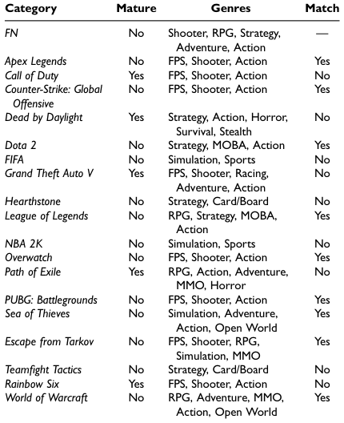

NOTE: complex table shown as an image of the PDF; the text below is a rough machine extraction and may be mis-aligned.

**extracted text (unreliable layout)**

Notes: RPG = role-playing game; FPS = first-person shooter; MOBA = multiplayer online battle arena; MMO = massively multiplayer online game.

154 Journal of Marketing Research 63(1)

Page 7

reported in Table W1 in the Web Appendix. If the estimated coefficients on eventft and updateft are statistically insignificant in both regressions, we retain unit k in our control unit pool for further analysis. Through this procedure, we identify 5 qualified control units from the top 20 categories: Apex Legends, Dota 2, Escape from Tarkov, League of Legends, and Sea of Thieves.<sup>4</sup>

#### Treatment and Control Streamers for Individual-Level Analysis

For the individual-level analysis, we consider nonstar streamers who actively streamed FN-related content as our treatment group. In the two months before Ninja’s exit, 17,006

English-speaking streamers had broadcast at least 1,000 minutes of FN-related content. These 17,006 active FN streamers accounted for 99% of FN’s total views on Twitch, while the remaining 1% came from 49,216 streamers who were inactive in FN broadcasting during that period. The live streaming market is a long-tail market where a small number of major streamers command most of the market share. The FN category is no exception: Among the 17,006 active FN streamers, the top 3% accounted for 80% of total views and 90% of the follower base within the category. To investigate the heterogeneous effects of a star creator’s exit on major creators versus micro creators, we construct two samples from the 17,006 active FN streamers. First, we construct a sample of major FN creators by collecting data from all top 3% FN streamers who are ranked by their viewership in the pre-exit period. This sample consists of 508 streamers. Second, we draw a stratified random sample of 516 streamers from the remaining 16,498 micro streamers. This involves ranking the streamers by total hours watched, dividing them into 516 subgroups based on rank, and randomly selecting one streamer from each subgroup. Given the similarities among streamers within each stratum, this stratification ensures the sample is representative of micro streamers while keeping the estimation tractable. In sum, our treatment group sample includes 1,024 FN streamers.

For the control group, we apply the same selection process to nonstar streamers across the five previously identified control categories. For each category, we construct two samples: the first consists of all major streamers, and the second is a stratified random sample of the micro streamers. In total, the control group includes 945 streamers: 404 major streamers and 541 micro streamers.

We report summary statistics of our sample in Table 3. For each streamer i, we calculate daily total broadcast time in their focal category to construct durationit, our primary measure of content provision at the individual level. If streamer i did not broadcast in the focal category on day t, we set durationit to zero. The average daily streaming duration for the treatment group of major streamers declined from 211 minutes to 161

Table 2. Category-Level Summary Statistics (Ninja’s Exit).

[output not shown]

NOTE: table converted from PDF layout to HTML text; cell boundaries are reconstructed. See PDF if exact alignment matters.

Notes: Apex = Apex Legends; LOL = League of Legends; SOT = Sea of Thieves; EFT = Escape from Tarkov.

4 We also repeat the control group selection procedure starting from the top 100 categories and confirm that the estimation results remain robust. 5 The spike of Dota 2 following the exit is driven by a major esports event in that category.

Qian and Xie 155

Page 8

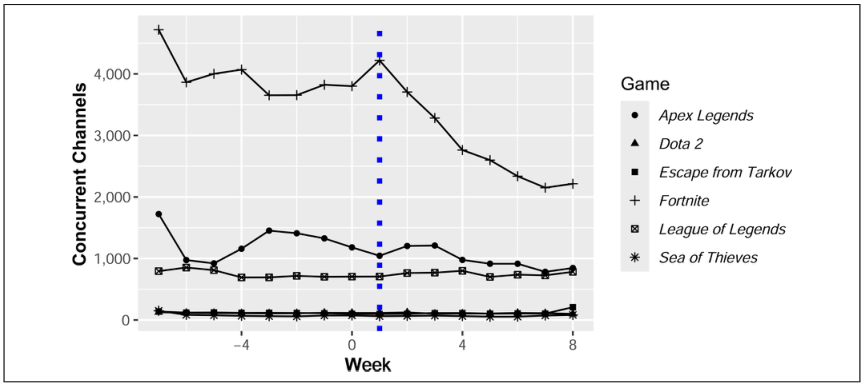

NOTE: figure/graphic rendered as an image from the PDF; its content is not machine-readable text. Caption (if any) follows as the next block.

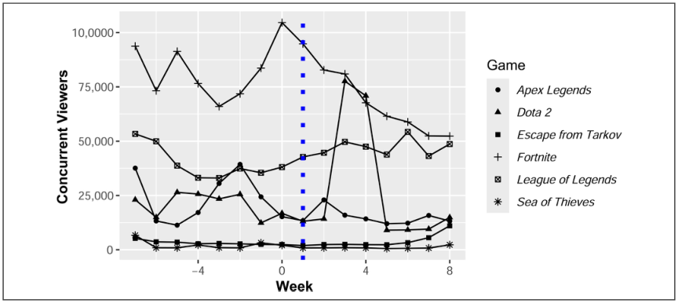

NOTE: figure/graphic rendered as an image from the PDF; its content is not machine-readable text. Caption (if any) follows as the next block.

minutes after Ninja’s exit, while the streamers in the control group categories incurred a smaller reduction in streaming duration during the same period. We use viewersit, the average number of concurrent viewers watching streamer i’s focal category streaming on day t, to measure content consumption at the individual streamer level. From Table 3, we observe that FN major streamers attracted an average of 689 daily concurrent viewers before the exit, and 729 concurrent viewers after the exit. Major streamers in the control group categories attracted 628 daily concurrent viewers in the pre-exit period and 732

concurrent viewers in the postexit period. Micro streamers exhibit a qualitatively similar pattern, though with smaller magnitudes.

#### Causal Inference Approach

A key challenge in our causal inference is the presence of nonparallel pretreatment trends between the treatment and control units, as shown in Figures 2 and 3. This violates the parallel trends assumption required for DiD estimation. The synthetic

Figure 2. FN Concurrent Channels Versus Control Categories’ Concurrent Channels.

Figure 3. FN Concurrent Viewers Versus Control Categories’ Concurrent Viewers.

156 Journal of Marketing Research 63(1)

Page 9

control method (SCM), introduced by Abadie, Diamond, and Hainmueller (2010), addresses this issue by constructing a weighted combination of control units under three key assumptions: (1) the treated unit and its synthetic control do not have a constant difference (i.e., zero-intercept), (2) the weights assigned to control units sum to one, and (3) equal weights are assigned across the time period of analysis. However, our treatment category, FN, substantially exceeds all control categories in terms of concurrent channels and viewers. As a result, implementing SCM would place a disproportionately large weight on a single control category which is the closest in magnitude but does not necessarily exhibit a pretreatment parallel pattern with FN.

Doudchenko and Imbens (2016) propose the modified synthetic control (MSC) method to relax SCM’s assumptions but do not offer clear guidance on which assumption(s) should be relaxed. To address this, Li and Shankar (2024) introduce the two-step synthetic control (TSC) method, which helps determine when to use SCM versus MSC based on the performance of pretreatment parallel trend tests. Following Li and Shankar (2024), we apply TSC tests to determine the synthetic control specification before conducting causal inference estimation. We construct separate synthetic controls for each of the four outcome variables (i.e., channelskt and viewerskt for categorylevel analysis, and durationit and viewersit for individual-level analysis).<sup>6</sup>

After determining the synthetic control specification, we implement SDiD, proposed by Arkhangelsky et al. (2021), to estimate causal effects at both the category level and individual level. Both DiD and SCM are nested within SDiD and can be considered special cases of SDiD. In our case, SDiD offers advantages over SCM, as it allows for the inclusion of two-way fixed effects and mitigates the estimation bias caused by control unit heterogeneity and time dynamics (Lambrecht, Tucker, and Zhang 2024). Additionally, SDiD

enables us to apply a consistent causal inference approach across different levels of data aggregation.

#### SDiD Analysis

In this subsection, we construct two sets of SDiD models to test our hypotheses: one at the category level and another at the individual level. The category-level SDiD model compares the treatment unit (the FN category) with the synthetic control unit, which is constructed from the five control categories. The individual-level SDiD model compares active FN streamers with a synthetic control group, constructed from active streamers focusing on the five control categories. Both models incorporate two-way fixed effects to improve the identification of causal effects.

Category-level model. To test the category-level hypothesis (H1), we analyze how average daily concurrent channels (channels) and average daily concurrent viewers (viewers) in the treated categories respond to the star creator’s exit. The classic DiD model of the average treatment effect would be:

ykt = μ + Wktτ + XktΓkt + αk + βt + ϵkt, (1)

where ykt ∈{viewers, channels} are dependent variables. We have one treated category, FN, and five control categories, where subscript k represents the category, and t indicates the day of streaming activity. μ is the intercept, and Wkt is a dummy variable that equals 1 if category k is affected by the star creator’s exit at day t and 0 otherwise. The focal estimator, τ, captures the average treatment effect for our category-level analysis. Xkt contains a vector of control variables, and Γkt is a vector of the associated coefficients. The first control variable we include is seasonkt, a dummy variable that equals 1 if category k launched a new game season on day t and 0 otherwise. This variable captures the potential spillover effects from the new game season releases on related streaming activities. Additionally, we include two control variables to capture key marketing activities for each game: updatekt, which equals 1 if game k had a version update on day t, and esportskt, a dummy variable indicating whether

Table 3. Individual-Level Summary Statistics (Ninja’s Exit).

[output not shown]

NOTE: table converted from PDF layout to HTML text; cell boundaries are reconstructed. See PDF if exact alignment matters.

6 Since the value of viewers is much larger than that of channels, using identical synthetic control weights for both would disproportionately emphasize viewers. This would overlook categories with similar supply patterns but different demand patterns, thus impairing supply-side matching. To enhance the quality of matching, we calculate separate weights for each outcome measure.

Qian and Xie 157

Page 10

category k hosted a major esports event on day t.<sup>7</sup> The error terms ϵkt capture the unobservable category-day-specific factors. The error terms for the two models (i.e., viewers and channels) are assumed to be normally distributed with zero mean and independent of each other. Following Arkhangelsky et al. (2021), we first regress the outcome variable on the control variables seasonkt, updatekt, and esportskt, and then use the resulting residuals as the dependent variable in our SDiD estimation.<sup>8</sup> We use the hat symbol (e.g., channels) to denote the calculated residual outcome variables throughout the remainder of this article.

Next, we describe the SDiD estimators. First, we estimate the SDiD weights of control units, specifically ω, a set of weights assigned to the unit of analysis, and λ, a set of weights assigned to the time of analysis, following Arkhangelsky et al. (2021). Denoting by N the total number of categories and by T the total number of days, we obtain the SDiD estimators by solving the following optimization problem:

(2)

where ykt indicates the outcome variable, either channelskt or viewerskt. Given the TSC test results, we relax the assumption that weights sum to one for both models and release the zero-intercept assumption for the model of viewers.

The synthetic control weights on the units of analysis for FN channels and viewers are reported in Table 4. To test the pretreatment parallel trend, we leverage estimators from a dynamic DiD model that captures differences between the treated unit and the weighted control units in all ten-day time intervals throughout our study period (see Sun and Abraham 2021 for an application of this approach). We label the nth ten-day interval after Ninja’s exit as n, the first ten-day interval before the exit as 0, and the nth ten-day interval before the exit as −n + 1. In Figures 4 and 5, we present the results of

pretreatment parallel trend tests. Our findings indicate that the difference between the treated unit and the synthetic control during the benchmark period (i.e., the first pretreatment ten-day interval) is statistically indistinguishable from differences in other pretreatment periods, suggesting the pretreatment outcomes exhibit a parallel trend between the treated unit and the synthetic control unit.

Results of category-level model. Table 5 presents the estimates from our category-level model. The first column reports the estimated effect on viewers, and the second column reports the estimated effect on channels. We find a statistically significant decline in the average number of concurrent viewers following Ninja’s exit. Specifically, Ninja’s exit resulted in a drop of 15,197 concurrent viewers (τ = −15,197.70, p < .001). This corresponds to an 18% decrease from the pre-exit average and approximately .71 standard deviations, supporting our hypothesis that a star creator’s exit contracts the total content consumption. We also find a significant reduction in the average number of concurrent FN channels following Ninja’s exit (τ = −1,001.74, p < .001), consistent with our hypothesis that a star creator’s exit leads to a decline in total content provision volume. This represents a 26% decline from the pre-exit average and corresponds to 3.81 standard deviations. In summary, our category-level analysis yields strong support for H1, demonstrating that a star creator’s exit has a negative net effect on both content consumption and provision at the category level.

Individual-level model. The individual-level content provision model is defined as follows:

durationit = μd + Witτd + XitΓitd + αid + βid + ϵitd, (3)

where durationit is the dependent variable, i indicates an individual streamer, and t indicates the day of streaming activity. durationit measures streamer i’s daily streaming duration (in minutes) in their focal category on day t, capturing their content provision. The subscript d indicates that the coefficient is associated with the model of durationit. Wit is a dummy variable that equals 1 if streamer i is affected by the star creator’s exit event and 0 otherwise. τd is the parameter of interest, representing the average treatment effect on the treated. Control variables (Xit) and fixed effects (α and β) are defined similarly to those in the category-level model. Lastly, the error term ϵitd captures the unobservable streamer-day-specific factors and is assumed to be normally distributed with a mean of zero. To obtain the SDiD estimates, we implement the same estimation procedure as in the category-level analysis. Based on the TSC test results, we relax the zero-intercept assumption in the SDiD specification.

The model of streamer-level content consumption is defined as follows:

log(viewersit) = μv + Witτv + XitΓitv + αiv + βiv + ϵitv, (4)

where viewersit represents the number of concurrent viewers for

Table 4. Synthetic Control Weights for Ninja’s Exit.

[output not shown]

NOTE: table converted from PDF layout to HTML text; cell boundaries are reconstructed. See PDF if exact alignment matters.

Notes: Apex = Apex Legends; LOL = League of Legends; EFT = Escape from Tarkov; SOT = Sea of Thieves.

7 For example, the 2019 Fortnite World Cup started on July 26 and lasted three days, while the 2019 League of Legends World Championship Final was held on November 10. 8 We also incorporate lagged variables in the regressions teasing off exogenous event effects and observe that the effects on the lagged variables of updatekt and esportskt are insignificant, suggesting that the effect of these events are shortlived. The effect of seasonkt becomes insignificant after six days, so we include lagged variables of seasonkt when we calculate the residuals.

158 Journal of Marketing Research 63(1)

Page 11

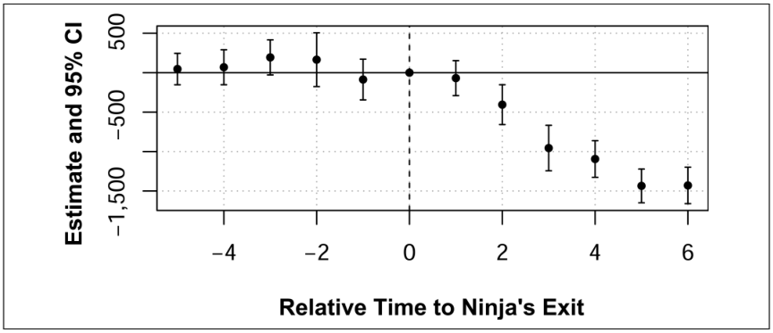

NOTE: figure/graphic rendered as an image from the PDF; its content is not machine-readable text. Caption (if any) follows as the next block.

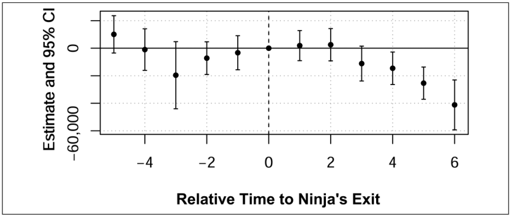

NOTE: figure/graphic rendered as an image from the PDF; its content is not machine-readable text. Caption (if any) follows as the next block.

streamer i on day t when broadcasting their focal category. We apply a logarithmic transformation to viewersit to account for the highly right-skewed distribution of viewership across streamers. To avoid undefined values when viewersi,t = 0, we add one before taking the logarithm. Note that we only observe viewersit if streamer i starts a live session in their focal category on day t. The error term ϵitv is assumed to be normally distributed with a mean of zero and independent of ϵitd. The other variables and parameters are defined similarly to those in Equation 3. For the SDiD weights estimation in the individual-level content consumption model, the TSC test

results suggest that we relax both the weights-sum-to-one assumption and the zero-intercept assumption.<sup>9</sup>

We estimate the treatment effects of a star creator’s exit at the individual level using two groups: the major streamer sample (denoted as Sample 1) and the stratified micro streamer sample (denoted as Sample 2). Comparing the estimated effects across these two samples allows us to examine heterogeneous

Figure 5. Concurrent Viewers Point Estimates of the Dynamic DiD at Ten-Day Level.

Figure 4. Concurrent Channels Point Estimates of the Dynamic DiD at Ten-Day Level.

9 We choose not to report the SDiD weights for individual-level analysis because the number of control units is large.

Qian and Xie 159

Page 12

treatment effects due to their distinct positions on the popularity spectrum, as hypothesized in H2.<sup>10</sup> In addition, we construct a third sample (denoted as Sample 3), which consists of a 3% stratified random draw from Sample 1 and all of the micro streamers from Sample 2. Sample 3 is equivalent to a stratified random sample from the active streamer population in each streaming category, capturing 3% of the total population. The estimation results based on Sample 3 better reflect the average treatment effect at the individual streamer level across the entire active streamer population.

To test H3, which examines the heterogeneous effects between contracted and noncontracted streamers, we leverage information on a Twitch streamer’s participation in the Twitch Partner Program (TPP). To qualify for TPP, a streamer must broadcast for at least 25 hours across 12 days and attract an average of 75 concurrent viewers within a 30-day period. Among the Twitch streamers in both the treated and control categories, partnered streamers have an average of 96,120 followers and attract 560 average concurrent viewers daily, whereas nonpartnered streamers have only 854 followers and attract an average of 6 concurrent viewers daily. TPP partners not only benefit from more monetary rewards but also demonstrate a higher level of commitment to content provision than nonpartnered Twitch streamers due to the program’s partnership policy restrictions. Thus, we classify partnered streamers as contracted streamers with high commitment to content production, while nonpartnered streamers are considered noncontracted streamers with lower commitment.

H3 suggests that contracted streamers’ content provision is less affected by a star creator’s exit than that of noncontracted streamers. To test this, we define a dummy variable Partner = 1 if a streamer is enrolled in TPP, and Partner = 0 otherwise. We then add an interaction term between Wit and Partner in Equation 3 to estimate the heterogeneous treatment effects between partnered streamers and nonpartnered streamers. A significant and positive estimate of the corresponding coefficient τP would indicate support for H3.

In our major streamer sample, the treated group consists of 310 partnered streamers and 198 nonpartnered streamers, while the control group includes 308 partnered streamers and 96 nonpartnered streamers. In the micro streamer sample, the treated group consists of 18 partnered streamers and 498 nonpartnered streamers, while the control group consists of 29 partnered streamers and 512 nonpartnered streamers. Because most partnered streamers are also major creators, we focus on Sample 1 when analyzing heterogeneous treatment effects by contract status.

Results of individual-level model. Tables 6 and 7 present the estimation results from our individual-level analysis. In each table, the first column reports estimates from the main model specified in Equations 3 and 4 using Sample 1. The second column shows the estimation results from the model that incorporates the interaction term between Wit and Partner using Sample 1. Similarly, the third and fourth columns present results from Sample 2, and the last two columns report results from Sample 3. All standard errors are clustered at the streamer level. Our results suggest that Ninja’s exit reduced the daily broadcasting duration of major incumbent FN streamers by approximately 15 minutes (τ = −15.74, p = .01), or 8% of their pre-exit average. For micro streamers, the estimated effect was a 6-minute reduction in daily streaming duration, representing a smaller reduction of 6% in their average daily streaming duration. However, the effect is not statistically significant (τ = −6.67, p = .11). For Sample 3, which includes both major streamers and micro streamers, streaming duration decreased by about 7 minutes (τ = −7.53, p = .07), equivalent to 7% of their pre-exit average.

Comparing the treatment effect estimates on content provision at the category and individual levels reveals a discrepancy in magnitude when expressed as a percentage term: 26% reduction at the category level versus 7% at the individual streamer level for Sample 3. This discrepancy arises from how content provision is measured at each level. The category-level measure (channels) reflects the total number of daily concurrent channels, including both channels that primarily broadcast content related to the gaming category and channels operated by streamers who only occasionally stream related content. In contrast, the individual-level measure (duration) captures only the daily content provision quantity of active streamers who focus on the category.

Regarding changes in content consumption, we find that major FN streamers experienced an approximately 22% decrease in daily concurrent viewers (τ = −.22, p < .001). For FN micro streamers, the average treatment effect on viewers was a decrease of approximately 7% in concurrent viewers (τ = −.07, p = .02). The average effect in Sample 3 was a 9% decrease in concurrent viewers (τ = −.09, p = .02). These findings support H2, which predicts that a star creator’s exit has a greater impact on major streamers than on micro streamers. Major FN streamers reduced their content production by about 8% compared with their pre-exit production level but experienced a 22% decline in daily concurrent viewers. We suspect that the overall contraction in the market size following

Table 5. Category-Level Parameter Estimates (Ninja’s Exit).

[output not shown]

NOTE: table converted from PDF layout to HTML text; cell boundaries are reconstructed. See PDF if exact alignment matters.

Notes: Robust standard errors are reported.

10 Alternatively, we could include an interaction term between a major streamer indicator and Wit to identify the heterogeneous treatment effects using Sample 3. However, this approach lacks statistical power due to the imbalance in sample sizes between major streamers (3%) and micro streamers (97%).

160 Journal of Marketing Research 63(1)

Page 13

the star creator’s exit may have driven this greater decline in content consumption. The estimated treatment effects on content consumption are more comparable across levels: an 18% reduction at the category level versus a 22% reduction at the individual level for Sample 1. This is because major streamers contribute a disproportionately large share of the total viewership within the category.

Next, we discuss the estimation results for heterogeneous effects between partnered versus nonpartnered streamers, reported in the second, fourth, and sixth columns of Tables 6 and 7. The estimation results from Sample 1 suggest that, compared with nonpartnered major streamers in the treated group, the negative effect of Ninja’s exit was mitigated among partnered major streamers for both outcome measures (τP = 47.59, p < .001 for streaming duration; τP = .08, p = .10 for concurrent viewers).<sup>11</sup> A further calculation, incorporating both the main effect and the interaction effect, suggests that partnered major streamers tended to maintain their daily broadcasting duration at pre-exit levels following the star creator exit (the sum of these two estimates is positive but statistically

insignificant at the 5% level as p = .81). These differences are statistically insignificant in the other two samples, which is expected, given the very small proportion of partnered streamers among micro streamers in these samples. We also note that partnered streamers, on average, have higher popularity than nonpartnered streamers in terms of viewership and follower base. The popularity of streamers could potentially confound the effect of contract status. To rule out this possibility, Table W2 in Appendix A shows that the heterogeneous effects associated with Twitch partnership remain robust after controlling for streamer popularity (measured by their pre-exit viewership market share). Thus, our findings support H3.

Time-varying effect of star creator exit. While our primary analysis assumes a static exit effect, it is important to examine whether the effect follows a dynamic pattern. To investigate this, we extend our SDiD models to estimate average treatment effects across successive postexit time intervals. Specifically, the treatment effect for the nth ten-day interval is denoted as τn. The estimation results are presented in Tables 8 and 9.

In the category-level analysis, the number of concurrent viewers in the FN category (in thousands) does not decline immediately following the star creator’s exit. The effect becomes significantly negative after the second ten-day

Table 6. Individual-Level Duration Parameter Estimates (Ninja’s Exit).

[output not shown]

NOTE: table converted from PDF layout to HTML text; cell boundaries are reconstructed. See PDF if exact alignment matters.

Notes: TWFE = two-way fixed effects. Sample 1 is a sample of all major streamers, Sample 2 is a stratified sample of micro streamers, and Sample 3 is a stratified sample of all streamers. τ denotes treatment effect and τP denotes the heterogenous effect between partnered and nonpartnered streamers. Standard errors are clustered by streamer.

Table 7. Individual-level Concurrent Viewers Parameter Estimates (Ninja’s Exit).

[output not shown]

NOTE: table converted from PDF layout to HTML text; cell boundaries are reconstructed. See PDF if exact alignment matters.

Notes: TWFE = two-way fixed effects. Sample 1 is a sample of all major streamers, Sample 2 is a stratified sample of micro streamers, and Sample 3 is a stratified sample of all streamers. τ denotes treatment effect and τP denotes the heterogenous effect between partnered and nonpartnered streamers. Standard errors are clustered by streamer.

11 We also examine the effects separately for partnered and nonpartnered streamers. The average treatment effect is negative for both groups, though the effect for the partnered sample is statistically insignificant.

Qian and Xie 161

Page 14

#### Robustness Checks

Exit of Shroud. We employ the same procedure used in the main analysis to estimate the effect of Shroud’s exit. Apex Legends, Minecraft, Escape from Tarkov, and PUBG: Battlegrounds are selected as the treated categories, as these four games were Shroud’s most-streamed titles and accounted for 63% of his total broadcast time before his exit. On average, 1,430 channels concurrently live streamed Apex Legends–related content, attracting 27,450 concurrent viewers per day in 2019. The average daily concurrent channels for Minecraft in 2019 was 946, with an average of 20,262 daily concurrent viewers. The corresponding figures for Escape from Tarkov and PUBG: Battlegrounds were 317 channels and 9,405 viewers, and 1,228 channels and 28,349 viewers, respectively. The study period for Shroud’s exit consists of a pre-exit period from August 25 to October 23 and a postexit period from October 24 to December 22, forming a 120-day study window, consistent with the main analysis of Ninja’s exit. In addition, we exclude non-English streaming channels, as Shroud primarily streamed in English.

Following the same control category selection procedure as in our main analysis, we include seven categories in the

control group: 7 Days to Die, League of Legends, Sea of Thieves, Tom Clancy’s Rainbow Six Siege, Path of Exile, World of Tanks, and World of Warships.<sup>12</sup> As in the analysis of Ninja’s exit, we examine the dynamic pattern before and after the treatment and confirm that the treated categories and the synthetic control exhibit a pretreatment parallel trend (see Figures W9 and W10). The category-level estimates are reported in Table 10. In summary, Shroud’s exit led to an average decline of 2,001 concurrent viewers per treated category (τ = −2,001.44, p < .001) and a reduction of 76 concurrent channels per treated category (τ = −76.15, p < .001). These estimates translate into an 18.7% decrease in concurrent viewers and a 15.9% decrease in concurrent channels relative to pre-exit levels. These results are qualitatively consistent with those for Ninja’s exit, offering additional support for H1.

Next, we conduct the individual-level analysis where the treatment group comprises streamers who focus on the same four treated categories as in the category-level analysis: Apex Legends, Minecraft, Escape from Tarkov, and PUBG: Battlegrounds. The control group comprises active streamers from the seven control categories. In the sample of major streamers (Sample 1), we include 342 streamers in the treatment group and 305 streamers in the control group. In the stratified sample of micro streamers (Sample 2), we include 351 streamers in the treatment group and 321 streamers in the control group. In the stratified sample of the population (Sample 3), we include 363 streamers in the treatment group and 331 streamers in the control group. The individual streamer-level estimation results are reported in Tables 11 and 12.

We find that Shroud’s exit led to a significant decline in incumbent major streamers’ broadcasting duration on content related to the four treated categories, reducing their daily streaming time by approximately 16 minutes (τ = −16.03, p = .03). The effects in the other two samples are negative but statistically insignificant. However, when examining the effects on viewership, we find that Shroud’s exit does not have a statistically significant effect in any of the three samples. We suspect this is because Shroud had a smaller follower base in the focal categories and was a more diversified streamer than Ninja, broadcasting content across more than 20 categories, which resulted in a weaker influence on content consumption within any single affected category. In summary, H2 is partially supported in the case of Shroud’s exit.

Additionally, we test the heterogeneous treatment effects between partnered streamers and nonpartnered streamers. Consistent with H3, the estimates reported in the second column of Tables 11 and 12 indicate that the negative effect of Shroud’s exit is mitigated among partnered streamers for both streaming duration (τP = 33.51, p = .02) and concurrent

Table 8. Time-Varying Treatment Effects at Category Level (Ninja’s Exit).

[output not shown]

NOTE: table converted from PDF layout to HTML text; cell boundaries are reconstructed. See PDF if exact alignment matters.

Notes: TWFE = two-way fixed effects. Robust standard errors are reported.

12 We select them from the top 50 Twitch gaming categories to ensure a sufficient number of control units.

162 Journal of Marketing Research 63(1)

Page 15

viewers (τP = .14, p = .04). Overall, we find that the results of Shroud’s exit are largely consistent with those of Ninja’s exit at both the category level and individual level, reinforcing our hypotheses.

#### Conclusion and Implications

In this article, we examine the role of star creators in digital content markets, focusing on how their exit influences both content provision and consumption. Using a quasi-experimental approach, we analyze the effects of Ninja and Shroud’s exits from Twitch and uncover several key insights:

1. The exit of a star creator shrinks content consumption. Our empirical research indicates that a star creator’s exit results in a substantial decline in content consumption in the market(s) associated with the star creator, as evidenced by fewer concurrent viewers in the affected content categories. This suggests that star creators function as key drivers of audience engagement, attracting and sustaining a significant portion of the consumer base. Our findings resonate with previous research on the demand-enhancing impact of star performers (e.g., Elberse 2007) and the research on the traffic loss due to a big supplier’s departure from the aggregator website (e.g., Chiou and Tucker 2017). Our findings also suggest that the loss of a star creator not only affects their direct followers but also diminishes the overall appeal of the content category, ultimately leading to a contraction in content consumption. 2. Content provision does not expand to compensate for a star creator’s absence; instead, it contracts. We find that overall content provision decreases following a star creator’s exit. This result may seem counterintuitive, as one might expect incumbent creators to increase content production to fill the gap and capture market share. However, two key factors could drive the opposite outcome. First, reduced audience size discourages content creators from investing effort in content

Table 9. Time-Varying Treatment Effects at Individual Level (Ninja’s Exit).

[output not shown]

NOTE: table converted from PDF layout to HTML text; cell boundaries are reconstructed. See PDF if exact alignment matters.

Notes: TWFE = two-way fixed effects. Sample 1 is a sample of all major streamers, Sample 2 is a stratified sample of micro streamers, and Sample 3 is a stratified sample of all streamers. Standard errors are clustered by streamer.

Table 10. Category-Level Parameter Estimates (Shroud’s Exit).

viewers channels

τ −2,001.44 −76.15 (427.03) (18.58) Category fixed effect Included Included Day fixed effect Included Included Observations 1,320 1,320 Adjusted R-squared .72 .89 Correlation of residuals — .31

Notes: Robust standard errors are reported.

Qian and Xie 163

Page 16

production, as they anticipate lower returns. Second, softened competition in content supply diminishes the incentives for innovation and high-quality content creation. In the context of a live streaming platform, we find that streaming categories affected by a star creator’s exit experience a decline in overall content provision. At the individual level, major nonstar creators from these categories reduce their streaming duration in response to the exit of a star creator. These findings underscore the critical role star creators play in sustaining and motivating content creation by nonstar creators. 3. The impact of a star’s exit is uneven across the creator spectrum. At the individual level, our findings suggest that the effects of a star creator’s exit on incumbents vary across different types of content creators. Contracted creators demonstrate higher commitment levels and exhibit greater resilience in content provision following the star creator’s exit, whereas noncontracted creators experience a more pronounced decline in both content demand and provision. Additionally, the adverse shock triggered by the exit event disproportionately affects major streamers compared with micro streamers. While contracted streamers are more prevalent among major streamers, major streamers overall still experience a larger reduction in both content provision

and viewership than micro streamers following the star creator’s departure. 4. The star’s exit casts a long shadow. Our empirical analysis reveals that the effects of a star creator’s exit persist over time, leading to a prolonged adjustment in content provision and a lasting decline in content consumption for both major and micro streamers. This sustained impact underscores the challenges in restoring equilibrium in the content market, highlighting the pivotal role star creators play in ensuring stability and engagement in digital content markets.

As content creation becomes an increasingly popular profession, digital content markets are experiencing an oversupply of content creators. However, audience attention tends to concentrate on a small group of top creators. To adapt to this highly concentrated content preference, platforms often allocate disproportionately high exposure to a select number of star creators, further widening the gap between star and nonstar creators. Our research emphasizes the central role of star creators in this ecosystem, shedding light on how their market exit reshapes the digital content ecosystem.

From a managerial perspective, our study suggests a new framework for assessing the value of a star creator. The presence of a star creator competing with many nonstar creators

Table 11. Individual-Level Duration Parameter Estimates (Shroud’s Exit).

[output not shown]

NOTE: table converted from PDF layout to HTML text; cell boundaries are reconstructed. See PDF if exact alignment matters.

Notes: TWFE = two-way fixed effects. Sample 1 is a sample of all major streamers, Sample 2 is a stratified sample of micro streamers, and Sample 3 is a stratified sample of all streamers. τ denotes treatment effect and τP denotes the heterogenous effect between partnered and nonpartnered streamers. Standard errors are clustered by streamer.

Table 12. Individual-Level Concurrent Viewers Parameter Estimates (Shroud’s Exit).

[output not shown]

NOTE: table converted from PDF layout to HTML text; cell boundaries are reconstructed. See PDF if exact alignment matters.

Notes: Sample 1 is a sample of all major streamers, Sample 2 is a stratified sample of micro streamers, and Sample 3 is a stratified sample of all streamers. τ denotes treatment effect and τ denotes the heterogenous effect between partnered and nonpartnered streamers. Standard errors are clustered by streamer.

164 Journal of Marketing Research 63(1)

Page 17

can stimulate greater content production. In practice, platforms often rely on demand-side metrics, such as subscriber count and content views, to evaluate a content creator’s value. However, incorporating supply-side metrics, such as network centrality among creators and the frequency of a creator’s content being referenced by others, could provide a more comprehensive assessment. Given that star creators significantly influence content production by other creators, these metrics could be crucial for fostering content innovation and quality enhancement.

Our research also provides valuable insights for digital content platforms navigating strategic investments in star creators, particularly regarding retention and acquisition. Our quasi-experiment demonstrates that the exit of Ninja, Twitch’s most prominent FN streamer, led to a substantial decline in content provision and consumption for FN-related content. Armstrong and Wright (2007) propose that e-commerce platforms sign exclusive contracts with sellers to prevent multihoming and mitigate platform competition on the supply side. Similarly, we have observed that platforms sign exclusive contracts with stringent penalty terms to deter star streamers from leaving. This approach has become more prevalent after Twitch’s loss of Ninja and Shroud (Goslin 2020). We recommend that platforms fully consider a star creator’s impact on the supply side when determining penalty terms in exclusive contracts. Platforms can refer to our study when assessing their investments in star creators.

The findings regarding heterogeneous effects support the idea that a market shock might not impact creators equally. Noncontracted creators, often smaller in scale and reach and less committed to producing content within the platform, face greater vulnerability to such shocks. Their content production and audience engagement often hinge on star creators’ vast followings. In contrast, contracted creators, armed with loyal fan bases and a strong commitment to content creation, are more insulated from these market shocks. Platforms should consider strategies to convert high-potential creators into contracted creators. Providing incentives, mentorship, and financial support for emerging streamers can help maintain content diversity and resilience in the ecosystem.

Our article is not without limitations, which we hope future research will address. First, we focus on the effect of a star creator’s exit on specialized content markets. Future research could extend our research to a platform-wide perspective. Second, our study focuses on the causal estimation of the effect of a star creator’s exit. Future work could try to decompose the underlying demand and supply shifts in response to a star creator’s entry or exit and separately identify the various pathways discussed in this article. Third, we do not have access to individual-level consumer data. The availability of such data would allow us to conduct additional analysis to further strengthen our validation of the SUTVA assumptions. Moreover, with individuallevel consumer data, future studies could explore whether the observed decline in content consumption is primarily driven by the departure of the star creator’s loyal audience. Fourth, our empirical analysis focuses on the live streaming market.

Future research could examine whether our findings generalize to other digital content markets, such as short videos or online novels. Lastly, we use streaming duration as the primary measure of creator effort. Future research could develop a broader set of metrics to better capture different dimensions of content creation effort.

Acknowledgments

The authors thank the JMR review team, Sanjay Jain, Dmitri Kuksov, Upender Subramanian, Nanda Kumar, Chenxi Liao, Dai Yao, Xiaolin Li, Xingyu Chen, Krista J. Li, and seminar participants at University of Texas at Dallas, University of Kentucky, University of North Carolina at Charlotte, Northeastern University, University of Massachusetts Amherst, Stevens Institute of Technology, and Indiana University for their helpful comments. The authors also thank Zonghao Li for his excellent research assistant work. This research received no specific grant from any funding agency in the public, commercial, or not-for-profit sectors. The usual disclaimer applies.

Coeditor

Raghuram Iyengar

Associate Editor

S. Sriram

Declaration of Conflicting Interests

The author(s) declared no potential conflicts of interest with respect to the research, authorship, and/or publication of this article.

Funding

The author(s) received no financial support for the research, authorship, and/or publication of this article.

ORCID iDs

Kun Qian https://orcid.org/0000-0002-1968-9149 Ying Xie https://orcid.org/0000-0003-4573-7797

References

Abadie, Alberto, Alexis Diamond, and Jens Hainmueller (2010),

“Synthetic Control Methods for Comparative Case Studies: Estimating the Effect of California’s Tobacco Control Program,” Journal of the American Statistical Association, 105 (490), 493– 505. Ailawadi, Kusum L., Jie Zhang, Aradhna Krishna, and Michael

W. Kruger (2010), “When Wal-Mart Enters: How Incumbent Retailers React and How This Affects Their Sales Outcomes,” Journal of Marketing Research, 47 (4), 577–93. Akca, Selin and Anita Rao (2020), “Value of Aggregators,” Marketing

Science, 39 (5), 893–922. Arkhangelsky, Dmitry, Susan Athey, David A. Hirshberg, Guido

W. Imbens, and Stefan Wager (2021), “Synthetic Difference-in-Differences,” American Economic Review, 111 (12), 4088–4118.

Qian and Xie 165

Page 18

Armstrong, Mark and Julian Wright (2007), “Two-Sided Markets,

Competitive Bottlenecks and Exclusive Contracts,” Economic Theory, 32 (2), 353–80. Basuroy, Suman, Subimal Chatterjee, and S. Abraham Ravid (2003), “How

Critical Are Critical Reviews? The Box Office Effects of Film Critics, Star Power, and Budgets,” Journal of Marketing, 67 (4), 103–17. Chiou, Lesley and Catherine Tucker (2017), “Content Aggregation by

Platforms: The Case of the News Media,” Journal of Economics & Management Strategy, 26 (4), 782–805. Dean, Brian (2023), “Twitch Usage and Growth Statistics: How Many

People Use Twitch?” Backlinko (accessed December 15, 2023), https://backlinko.com/twitch-users. Doudchenko, Nikolay and Guido W. Imbens (2016), “Balancing,

Regression, Difference-in-Differences and Synthetic Control Methods: A Synthesis,” Working Paper 22791, National Bureau of Economic Research, https://www.nber.org/papers/w22791. Elberse, Anita (2007), “The Power of Stars: Do Star Actors Drive the

Success of Movies?” Journal of Marketing, 71 (4), 102–20. Gielens, Katrijn, Linda M. Van de Gucht, Jan-Benedict E.M. Steenkamp, and Marnik G. Dekimpe (2008), “Dancing with a Giant: The Effect of Wal-Mart’s Entry into the United Kingdom on the Performance of European Retailers,” Journal of Marketing Research, 45 (5), 519–34. Goli, Ali and Pradeep K. Chintagunta (2021), “What Happens When a

Retailer Drops a Product Category? Investigating the Consequences of Ending Tobacco Sales,” Marketing Science, 40 (6), 1169–98. Goslin, Austin (2020), “The Mass Twitch Exodus: Why Streamers Are

Leaving,” Polygon (January 27), https://www.polygon.com/2020/ 1/27/21043450/twitch-streamers-leaving-mixer-facebook-youtubeninja-shroud-disguisedtoast/. Gu, Xian, Xiaoxi Zhang, and P.K. Kannan (2024), “Influencer Mix

Strategies in Livestream Commerce: Impact on Product Sales,” Journal of Marketing, 88 (4), 64–83. Han, Shu and S. Abraham Ravid (2020), “Star Turnover and the Value

of Human Capital—Evidence from Broadway Shows,” Management Science, 66 (2), 958–78. Hayes, Adam (2024), “YouTube Stats: Everything You Need to Know

In 2024!,” Wyzowl (December 3), https://wyzowl.com/youtubestats/. Jain, Sanjay and Kun Qian (2021), “Compensating Online Content

Producers: A Theoretical Analysis,” Management Science, 67 (11), 7075–90. Jia, Panle (2008), “What Happens When Wal-Mart Comes to Town:

An Empirical Analysis of the Discount Retailing Industry,” Econometrica, 76 (6), 1263–1316. Kim, Matt (2019), “Twitch’s Restrictive Contract Drove Ninja to

Mixer Deal,” IGN (October 2), https://www.ign.com/articles/ 2019/10/02/ninja-twitch-contract-reason-for-leaving-mixer.

Kumar, Naveen (2025), “26 Essential YouTube Creator Statistics of

2025 [Global Data],” DemandSage (August 22), https://www. demandsage.com/youtube-creator-statistics/. Lambrecht, Anja, Catherine Tucker, and Xu Zhang (2024), “TV

Advertising and Online Sales: A Case Study of Intertemporal Substitution Effects for an Online Travel Platform,” Journal of Marketing Research, 61 (2), 248–70. Li, Hui and Kannan Srinivasan (2019), “Competitive Dynamics in the

Sharing Economy: An Analysis in the Context of Airbnb and Hotels,” Marketing Science, 38 (3), 365–91. Li, Kathleen T. and Venkatesh Shankar (2024), “A Two-Step

Synthetic Control Approach for Estimating Causal Effects of Marketing Events,” Management Science, 70 (6), 3734–47. Li, Xiaolin, Chenxi Liao, and Ying Xie (2021), “Digital Piracy, Creative

Productivity, and Customer Care Effort: Evidence from the Digital Publishing Industry,” Marketing Science, 40 (4), 685–707. Li, Xiaolin, Mengze Shi, and Clarice Zhao (2025), “Incentivizing Mass

Creativity: An Empirical Study of the Online Publishing Market,” Management Science (published online May 14), https://doi.org/ 10.1287/mnsc.2023.01566. Manchanda, Puneet, Asim Ansari, and Sunil Gupta (1999), “The

‘Shopping Basket’: A Model for Multicategory Purchase Incidence Decisions,” Marketing Science, 18 (2), 95–114. Orhun, A. Yeşim, Sriram Venkataraman, and Pradeep K. Chintagunta

(2016), “Impact of Competition on Product Decisions: Movie Choices of Exhibitors,” Marketing Science, 35 (1), 73–92. Ozturk, O. Cem, Sriram Venkataraman, and Pradeep K. Chintagunta

(2016), “Price Reactions to Rivals’ Local Channel Exits,” Marketing Science, 35 (4), 588–604. Robidoux, Brandy (2019), “Pro Gamer Ninja Shocks Fans by

Announcing He’s Leaving Twitch and Only Streaming on Mixer,” Hollywood Life (August 1), https://hollywoodlife.com/ 2019/08/01/ninja-leaves-twitch-mixer-announcement-tweet/. Seamans, Robert and Feng Zhu (2014), “Responses to Entry in

Multi-Sided Markets: The Impact of Craigslist on Local Newspapers,” Management Science, 60 (2), 476–93. Singh, Vishal P., Karsten T. Hansen, and Robert C. Blattberg (2006),

“Market Entry and Consumer Behavior: An Investigation of a Wal-Mart Supercenter,” Marketing Science, 25 (5), 457–76. Sun, Liyang and Sarah Abraham (2021), “Estimating Dynamic

Treatment Effects in Event Studies with Heterogeneous Treatment Effects,” Journal of Econometrics, 225 (2), 175–99. Tian, Zijun, Ryan Dew, and Raghuram Iyengar (2024), “Mega or

Micro? Influencer Selection Using Follower Elasticity,” Journal of Marketing Research, 61 (3), 472–95. Zervas, Georgios, Davide Proserpio, and John W. Byers (2017), “The

Rise of the Sharing Economy: Estimating the Impact of Airbnb on the Hotel Industry,” Journal of Marketing Research, 54 (5), 687–705.

166 Journal of Marketing Research 63(1)